# R Notebook

In this R Notebook I will give explanations and demonstrations of user created functions that assist in the Data collection, aggregation, and averaging process. Throughout I will refer to several files in this directory along with the functions written in those files.

The function of importance is “get.team.data” from **Helpful_Functions.R**, which retrieves box score data for every game of a specified team over an entire season. The function returns an object of class “All Season Data” (see same file). With a simple loop over all teams I have created the quintessential object used throughout this EDA: all.teams.data.

```r
source("Data Structuring/Helpful_Functions.R")
#Getting all game data from 20201 season
pth <- "~/Documents/Github /NBA-Model/Seasons_Data/2021"
#list that contains an S4 object for each team
all.teams.data <- c()
teams <- list.files(path=pth)

for (t in teams) {
  pth.t <- paste(pth, t, sep='/')
  all.teams.data[[t]] = get.team.data(t, '2021',pth.t)
}
```

all.teams.data is a compact object containing all and any box score from the 2021 season. We can query any box score (basic or advanced) from this object if we simply have a team abbreviation and game date.

Lets check out the box score for the most 3s by a team in 2020-2021 season

```r
team = 'MIL'
game = '12-29-2020'

#querying this game
print(all.teams.data[[team]]@player.basic[[game]])
```

| Players | MP | FG | FGA | FG. | X3P | X3PA | X3P. | FT | FTA | FT. | ORB | DRB | TRB | AST | STL | BLK | TOV | PF | PTS | X... |
| --- | --- | --- | --- | --- | --- | --- | --- | --- | --- | --- | --- | --- | --- | --- | --- | --- | --- | --- | --- | --- |
| Jrue Holiday | 26:10 | 9 | 15 | 0.600 | 6 | 10 | 0.600 | 0 | 0 | NA | 0 | 3 | 3 | 7 | 3 | 1 | 0 | 1 | 24 | 27 |
| Khris Middleton | 25:15 | 10 | 13 | 0.769 | 4 | 5 | 0.800 | 1 | 1 | 1.0 | 2 | 2 | 4 | 5 | 2 | 0 | 5 | 3 | 25 | 28 |
| Giannis Antetokounmpo | 24:14 | 3 | 9 | 0.333 | 0 | 2 | 0.000 | 3 | 5 | 0.6 | 0 | 6 | 6 | 6 | 3 | 0 | 2 | 2 | 9 | 23 |
| Donte DiVincenzo | 19:16 | 6 | 8 | 0.750 | 5 | 6 | 0.833 | 0 | 0 | NA | 0 | 1 | 1 | 2 | 2 | 0 | 1 | 2 | 17 | 28 |
| Brook Lopez | 18:11 | 4 | 5 | 0.800 | 3 | 4 | 0.750 | 3 | 3 | 1.0 | 0 | 2 | 2 | 0 | 0 | 0 | 1 | 1 | 14 | 22 |
| Bobby Portis | 26:20 | 4 | 10 | 0.400 | 1 | 3 | 0.333 | 2 | 2 | 1.0 | 3 | 6 | 9 | 1 | 1 | 0 | 2 | 4 | 11 | 27 |
| D.J. Augustin | 20:44 | 3 | 5 | 0.600 | 2 | 4 | 0.500 | 2 | 2 | 1.0 | 3 | 1 | 4 | 2 | 0 | 0 | 1 | 0 | 10 | 21 |
| Thanasis Antetokounmpo | 20:00 | 2 | 3 | 0.667 | 1 | 2 | 0.500 | 0 | 0 | NA | 1 | 4 | 5 | 4 | 1 | 0 | 4 | 2 | 5 | 23 |
| Bryn Forbes | 17:38 | 5 | 8 | 0.625 | 2 | 5 | 0.400 | 0 | 0 | NA | 0 | 2 | 2 | 1 | 0 | 0 | 1 | 2 | 12 | 9 |
| Pat Connaughton | 12:13 | 1 | 3 | 0.333 | 1 | 2 | 0.500 | 0 | 0 | NA | 0 | 2 | 2 | 3 | 1 | 1 | 0 | 0 | 3 | 15 |

[output cut: 3 more lines]

Now that we have a simple system for retrieving games in our R environment, we can wrangle the data and draw some insights. In the cell below, the code aggregates every players basic stat line for EVERY game in the season using *aggregate.players.data* from *Offensive_Stats.R*

```r
source("Data Structuring/Offensive_Stats.R")

players.agg.data <- aggregate.players.data(all.teams.data, "12-20-2020", "05-22-2021")
```

Lets check out some top performances this season and then the distribution of points scored by players who played at least 32 minutes, just to show how rare these performances are:

```r
data <- players.agg.data[[1]]
#returning top 6 highest Points scored games
head(arrange(data, desc(PTS)))
```

|  | Players | MP | FG | FGA | X3P | X3PA | FT | FTA | ORB | DRB | TRB | AST | STL | BLK | TOV | PF | PTS | X... | season.day | is.home | team |
| --- | --- | --- | --- | --- | --- | --- | --- | --- | --- | --- | --- | --- | --- | --- | --- | --- | --- | --- | --- | --- | --- |
| 1 | Stephen Curry | 36.45000 | 18 | 31 | 8 | 16 | 18 | 19 | 1 | 4 | 5 | 4 | 0 | 0 | 5 | 0 | 62 | 20 | 15 | 1 | GSW |
| 2 | Jayson Tatum | 45.33333 | 20 | 37 | 5 | 7 | 15 | 17 | 2 | 6 | 8 | 5 | 0 | 1 | 0 | 2 | 60 | 6 | 134 | 1 | BOS |
| 3 | Bradley Beal | 38.25000 | 20 | 35 | 7 | 10 | 13 | 15 | 4 | 3 | 7 | 5 | 1 | 0 | 4 | 3 | 60 | -9 | 18 | 0 | WAS |
| 4 | Stephen Curry | 37.06667 | 19 | 31 | 11 | 19 | 8 | 8 | 0 | 2 | 2 | 5 | 1 | 0 | 3 | 3 | 57 | 7 | 49 | 0 | GSW |
| 5 | Fred VanVleet | 37.10000 | 17 | 23 | 11 | 14 | 9 | 9 | 0 | 3 | 3 | 2 | 3 | 3 | 1 | 2 | 54 | 20 | 45 | 0 | TOR |
| 6 | Jayson Tatum | 41.00000 | 16 | 25 | 6 | 10 | 15 | 16 | 1 | 9 | 10 | 4 | 0 | 1 | 5 | 3 | 53 | 5 | 113 | 1 | BOS |

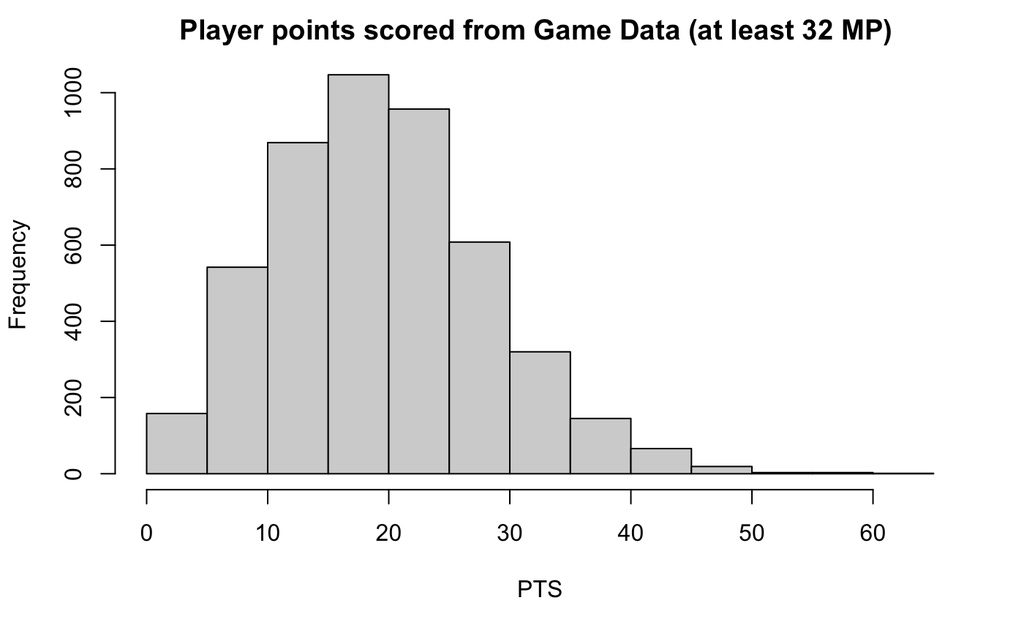

```r
f.data <- filter(data, MP > 32)

hist(f.data$PTS, main = "Player points scored from Game Data (at least 32 MP) ", xlab = "PTS")
```

With this aggregated data we have an entire seasons worth of player data condesley stored in a single data.frame. As result we can perform various types of data analysis through filtering, grouping, averaging, etc.

Lets use this data to visualize three point shooting styles for the Nets, Jazz, and Knicks:

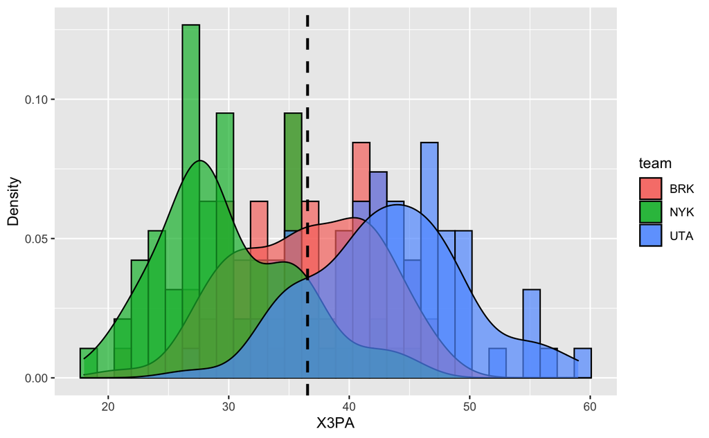

```r
library(ggplot2)
#list of dates that match season.day variable with a char of date for indexing
dates <- players.agg.data[[3]]
b.data <- players.agg.data[[1]]
#game data aggregated by team and day
team.data <- group_by(b.data, team, season.day) %>%
  summarise_each(sum, -Players) %>%
  mutate( is.home = is.home >0)

#plotting  3-point shooting trends across teams
dat <- filter(team.data, team %in% c('BRK', 'UTA', 'NYK'))
plot_multi_histogram(dat, 'X3PA', 'team')
```

```r
NA
NA
```

As you can see, the Utah Jazz shoots a higher frequency of threes than other teams, and the Knicks shoot far less (but has a tigher distribution). The Nets on the other hand vary more game to game in how many 3s they shoot (likely a result of various different lineups throughout the season).

Now an important task to address is organizing averages for players (and teams), not just at our current state but at any given point in time. After all, when we make predictions with our model, we would only have access to data prior to that game in time. For this task I have created averaging functions and classes that convienently store averages at specified points in time. Below I will create a said averages object using *get.players.averages* from *Offensive_Stats*

```r
source("Data Structuring/Offensive_Stats.R")
all.player.averages <- get.players.averages(players.agg.data[[1]], players.agg.data[[2]], players.agg.data[[3]])
```

Lets take a look at the scoring title race this past season

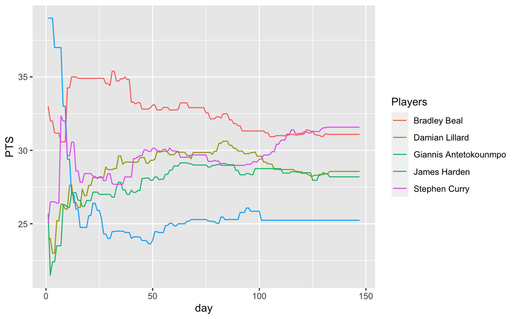

```r
#top scorers at the end of the year
top.scorers <- c('Bradley Beal', 'Damian Lillard', 'James Harden', 'Stephen Curry','Giannis Antetokounmpo')
#top.scorers <- head(all.player.averages@basic.mean$`05-22-2021`$Players)
games <- names(all.player.averages@basic.mean)
games <- games[9:length(games)]
#iterating through games, collecting averages for top 6 players
scores.df <- filter(all.player.averages@basic.mean[[games[1]]], Players %in% top.scorers) %>%
  select(c('Players', 'PTS')) %>%
  mutate(day = 1)
#iterating throough rest of the dates in the season
for (i in 2:length(games)) {
  new.rows <- filter(all.player.averages@basic.mean[[games[i]]], Players %in% top.scorers) %>%
    select(c('Players', 'PTS')) %>%
    mutate(day = i)
  #binding rows to data.frame
  scores.df <- bind_rows(scores.df, new.rows)
  i <- i + 1
}

#plotting using scores.df
ggplot(data=scores.df, aes(x=day, y=PTS, group = Players, colour= Players)) +
  geom_line()
```

```r
NA
NA
```

So one final main structural decision I made was aggregating this data and storing averages on a team-by-team level, eliminating the need to repeatedly filter data when working with specific teams. For this I have created storage classes *Season Averages* for a single team. Similarly there is *N Averages* which stores moving averages for a single team at each point in the season.

To demonstrate, lets look at the moving averages for Stephen Curry’s moving averages in that scoring spike at around the 100 day mark

| Players | MP | FG | FGA | X3P | X3PA | FT | FTA | ORB | DRB | TRB | AST | STL | BLK | TOV | PF | PTS | X... | is.home | win | games |
| --- | --- | --- | --- | --- | --- | --- | --- | --- | --- | --- | --- | --- | --- | --- | --- | --- | --- | --- | --- | --- |
| Stephen Curry | 31.64444 | 8.6666667 | 18.333333 | 4.0000000 | 9.000000 | 4.3333333 | 4.6666667 | 0.3333333 | 4.0000000 | 4.3333333 | 6.3333333 | 1.6666667 | 0.0000000 | 2.3333333 | 2.333333 | 25.666667 | 5.6666667 | 0.6666667 | 0.6666667 | 3 |
| Andrew Wiggins | 32.81667 | 8.1428571 | 15.714286 | 3.1428571 | 5.428571 | 3.4285714 | 4.4285714 | 1.1428571 | 4.5714286 | 5.7142857 | 2.1428571 | 1.5714286 | 0.1428571 | 2.2857143 | 2.142857 | 22.857143 | -0.4285714 | 0.4285714 | 0.4285714 | 7 |
| Jordan Poole | 29.61667 | 7.0000000 | 14.571429 | 2.8571429 | 7.285714 | 3.4285714 | 3.7142857 | 0.2857143 | 2.0000000 | 2.2857143 | 2.8571429 | 0.5714286 | 0.0000000 | 1.0000000 | 2.142857 | 20.285714 | -3.2857143 | 0.4285714 | 0.4285714 | 7 |
| Kelly Oubre | 31.30952 | 5.2857143 | 12.000000 | 1.1428571 | 4.285714 | 2.1428571 | 3.5714286 | 1.1428571 | 4.1428571 | 5.2857143 | 1.5714286 | 0.7142857 | 0.8571429 | 1.0000000 | 2.714286 | 13.857143 | -6.4285714 | 0.4285714 | 0.4285714 | 7 |
| James Wiseman | 26.61250 | 4.7500000 | 9.750000 | 0.0000000 | 1.000000 | 0.5000000 | 1.0000000 | 1.7500000 | 4.2500000 | 6.0000000 | 0.7500000 | 0.0000000 | 0.5000000 | 2.2500000 | 4.000000 | 10.000000 | -11.2500000 | 0.7500000 | 0.2500000 | 4 |
| Damion Lee | 19.43889 | 3.1666667 | 6.000000 | 1.6666667 | 3.500000 | 0.8333333 | 1.0000000 | 0.1666667 | 2.0000000 | 2.1666667 | 1.1666667 | 0.3333333 | 0.3333333 | 0.5000000 | 1.333333 | 8.833333 | -1.8333333 | 0.3333333 | 0.3333333 | 6 |
| Nico Mannion | 17.57143 | 2.2857143 | 6.142857 | 1.4285714 | 3.285714 | 1.4285714 | 1.4285714 | 0.2857143 | 1.2857143 | 1.5714286 | 2.8571429 | 0.8571429 | 0.0000000 | 0.5714286 | 1.428571 | 7.428571 | -4.8571429 | 0.4285714 | 0.4285714 | 7 |
| Draymond Green | 32.81667 | 2.6666667 | 6.333333 | 0.3333333 | 2.000000 | 1.6666667 | 1.8333333 | 1.3333333 | 8.3333333 | 9.6666667 | 8.3333333 | 1.5000000 | 1.1666667 | 3.0000000 | 3.000000 | 7.333333 | 0.1666667 | 0.5000000 | 0.5000000 | 6 |
| Eric Paschall | 15.11667 | 3.0000000 | 5.500000 | 1.0000000 | 1.500000 | 0.0000000 | 0.0000000 | 0.5000000 | 1.5000000 | 2.0000000 | 2.0000000 | 1.0000000 | 0.0000000 | 1.0000000 | 3.000000 | 7.000000 | -1.0000000 | 1.0000000 | 0.5000000 | 2 |
| Kevon Looney | 16.98333 | 2.0000000 | 3.000000 | 0.3333333 | 0.500000 | 0.3333333 | 0.6666667 | 1.1666667 | 2.6666667 | 3.8333333 | 2.0000000 | 0.6666667 | 0.8333333 | 0.8333333 | 2.000000 | 4.666667 | -4.0000000 | 0.5000000 | 0.5000000 | 6 |

[output cut: 5 more lines]